# PML Project Writeup

September 18, 2015

### Executive Summary

Using devices such as Jawbone Up, Nike FuelBand, and Fitbit it is now possible to collect a large amount of data about personal activity relatively inexpensively. These type of devices are part of the quantified self movement – a group of enthusiasts who take measurements about themselves regularly to improve their health, to find patterns in their behavior, or because they are tech geeks. One thing that people regularly do is quantify how much of a particular activity they do, but they rarely quantify how well they do it.

In this project, the goal will be to use data from accelerometers on the belt, forearm, arm, and dumbell of 6 participants. They were asked to perform barbell lifts correctly and incorrectly in 5 different ways. More information is available from the website here: http://groupware.les.inf.puc-rio.br/har (see the section on the Weight Lifting Exercise Dataset).

The training data for this project are available here: https://d396qusza40orc.cloudfront.net/predmachlearn/pml-training.csv

The test data are available here: https://d396qusza40orc.cloudfront.net/predmachlearn/pml-testing.csv

The data for this project come from the paper referenced below and downloaded here: http://groupware.les.inf.puc-rio.br/har .

Ugulino, W.; Cardador, D.; Vega, K.; Velloso, E.; Milidiu, R.; Fuks, H. Wearable Computing: Accelerometers’ Data Classification of Body Postures and Movements. Proceedings of 21st Brazilian Symposium on Artificial Intelligence. Advances in Artificial Intelligence - SBIA 2012. In: Lecture Notes in Computer Science. , pp. 52-61. Curitiba, PR: Springer Berlin / Heidelberg, 2012. ISBN 978-3-642-34458-9. DOI: 10.1007/978-3-642-34459-6_6.

### Data Processing

**Load required libraries**

```r
library(caret)
```

The data for the project has been downloaded as csv files from the links refernced in the executive summary.  
**Load the training data**

```r
x <- read.csv("pml-training.csv", na.strings=c("NA", ""))
dim(x)
```

```
## [1] 19622   160
```

```r
x[1:5,1:5]
```

```
##   X user_name raw_timestamp_part_1 raw_timestamp_part_2   cvtd_timestamp
## 1 1  carlitos           1323084231               788290 05/12/2011 11:23
## 2 2  carlitos           1323084231               808298 05/12/2011 11:23
## 3 3  carlitos           1323084231               820366 05/12/2011 11:23
## 4 4  carlitos           1323084232               120339 05/12/2011 11:23
## 5 5  carlitos           1323084232               196328 05/12/2011 11:23
```

**Load the test data**

```r
y <- read.csv("pml-testing.csv", na.strings=c("NA", ""))
dim(y)
```

```
## [1]  20 160
```

```r
y[1:5,1:5]
```

```
##   X user_name raw_timestamp_part_1 raw_timestamp_part_2   cvtd_timestamp
## 1 1     pedro           1323095002               868349 05/12/2011 14:23
## 2 2    jeremy           1322673067               778725 30/11/2011 17:11
## 3 3    jeremy           1322673075               342967 30/11/2011 17:11
## 4 4    adelmo           1322832789               560311 02/12/2011 13:33
## 5 5    eurico           1322489635               814776 28/11/2011 14:13
```

**Cleaning the data** is next, and first we need to remove all the columns with NA in them because they are summary based.

```r
x <-x[,colSums(is.na(x))==0]
y <-y[,colSums(is.na(y))==0]
```

Our next step is to convert to numeric data types and remove columns we know are not features.

```r
###convert all the features to numerics
for(i in 8:59){tmp <- typeof(x[,i]); if(tmp == "integer") x[,i]<- as.numeric(x[,i])}
for(i in 8:59){tmp <- typeof(y[,i]); if(tmp == "integer") y[,i]<- as.numeric(y[,i])}
#### remove un-needed columns
x<- x[,c(7:60)]
y<- y[,c(7:60)]
dim(x)
```

```
## [1] 19622    54
```

```r
dim(y)
```

```
## [1] 20 54
```

### Exploratory Data Analysis

```r
dim(x)
```

```
## [1] 19622    54
```

```r
names(x)
```

```
##  [1] "num_window"           "roll_belt"            "pitch_belt"
##  [4] "yaw_belt"             "total_accel_belt"     "gyros_belt_x"
##  [7] "gyros_belt_y"         "gyros_belt_z"         "accel_belt_x"
## [10] "accel_belt_y"         "accel_belt_z"         "magnet_belt_x"
## [13] "magnet_belt_y"        "magnet_belt_z"        "roll_arm"
## [16] "pitch_arm"            "yaw_arm"              "total_accel_arm"
## [19] "gyros_arm_x"          "gyros_arm_y"          "gyros_arm_z"
## [22] "accel_arm_x"          "accel_arm_y"          "accel_arm_z"
## [25] "magnet_arm_x"         "magnet_arm_y"         "magnet_arm_z"
## [28] "roll_dumbbell"        "pitch_dumbbell"       "yaw_dumbbell"
## [31] "total_accel_dumbbell" "gyros_dumbbell_x"     "gyros_dumbbell_y"
## [34] "gyros_dumbbell_z"     "accel_dumbbell_x"     "accel_dumbbell_y"
## [37] "accel_dumbbell_z"     "magnet_dumbbell_x"    "magnet_dumbbell_y"
## [40] "magnet_dumbbell_z"    "roll_forearm"         "pitch_forearm"
## [43] "yaw_forearm"          "total_accel_forearm"  "gyros_forearm_x"
## [46] "gyros_forearm_y"      "gyros_forearm_z"      "accel_forearm_x"
## [49] "accel_forearm_y"      "accel_forearm_z"      "magnet_forearm_x"
## [52] "magnet_forearm_y"     "magnet_forearm_z"     "classe"
```

```r
summary(x$classe)
```

```
##    A    B    C    D    E
## 5580 3797 3422 3216 3607
```

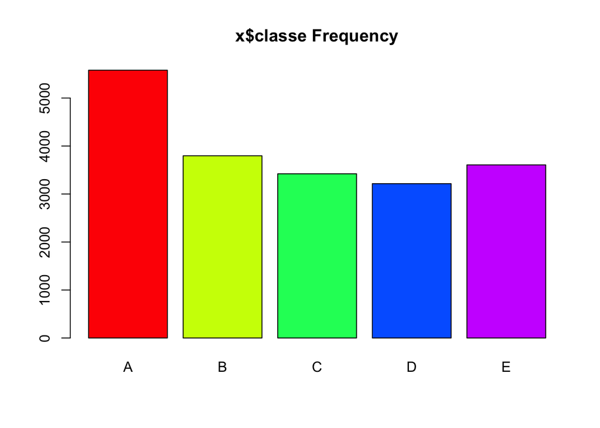

```r
plot(x$classe, col=rainbow(5), main="x$classe Frequency")
```

At this point we are ready to split the training set into two so we can have cross validation data later.

```r
### split into training and validation sets
inTrain <- createDataPartition(x$classe, p=0.70, list=FALSE)
trainx<- x[inTrain,]
validx<-x[-inTrain,]
dim(trainx)
```

```
## [1] 13737    54
```

```r
dim(validx)
```

```
## [1] 5885   54
```

### Model Fitting

We plan to use random forest for the model fit because of it’s high level of accuracy. We also with use the cross validation option with 5 folds.

```r
### fit a model using random forest
fit <- train(classe~.,data=trainx, method="rf", trControl = trainControl(method="cv", number = 5), prox = TRUE)
fit
```

```
## Random Forest
##
## 13737 samples
##    53 predictor
##     5 classes: 'A', 'B', 'C', 'D', 'E'
##
## No pre-processing
## Resampling: Cross-Validated (5 fold)
## Summary of sample sizes: 10990, 10990, 10991, 10989, 10988
## Resampling results across tuning parameters:
##
##   mtry  Accuracy   Kappa      Accuracy SD   Kappa SD
##    2    0.9933756  0.9916197  0.0009062577  0.001147162
##   27    0.9970885  0.9963171  0.0009954960  0.001259418
##   53    0.9934490  0.9917128  0.0018883682  0.002389582
##
## Accuracy was used to select the optimal model using  the largest value.
## The final value used for the model was mtry = 27.
```

### Calculating Accuracy in/out of sample

We expect the in sample accuracy to be very high in the range of 100 percent or almost 100 percent. The out of sample accuracy should be slightly less but still very high.

```r
train_ans<-predict(fit,trainx)
confusionMatrix(train_ans, trainx$classe)
```

```
## Confusion Matrix and Statistics
##
##           Reference
## Prediction    A    B    C    D    E
##          A 3906    0    0    0    0
##          B    0 2658    0    0    0
##          C    0    0 2396    0    0
##          D    0    0    0 2252    0
##          E    0    0    0    0 2525
##
## Overall Statistics
##
##                Accuracy : 1
##                  95% CI : (0.9997, 1)
##     No Information Rate : 0.2843
##     P-Value [Acc > NIR] : < 2.2e-16
##
##                   Kappa : 1
##  Mcnemar's Test P-Value : NA
##
## Statistics by Class:
##
##                      Class: A Class: B Class: C Class: D Class: E
## Sensitivity            1.0000   1.0000   1.0000   1.0000   1.0000
## Specificity            1.0000   1.0000   1.0000   1.0000   1.0000
## Pos Pred Value         1.0000   1.0000   1.0000   1.0000   1.0000
## Neg Pred Value         1.0000   1.0000   1.0000   1.0000   1.0000
## Prevalence             0.2843   0.1935   0.1744   0.1639   0.1838
## Detection Rate         0.2843   0.1935   0.1744   0.1639   0.1838
## Detection Prevalence   0.2843   0.1935   0.1744   0.1639   0.1838
## Balanced Accuracy      1.0000   1.0000   1.0000   1.0000   1.0000
```

The confusionMatrix above shows that our in_sample accuracy is equal to 1 which is 100%.

```r
valid_ans<-predict(fit,validx)
confusionMatrix(valid_ans, validx$classe)
```

```
## Confusion Matrix and Statistics
##
##           Reference
## Prediction    A    B    C    D    E
##          A 1674    1    0    0    0
##          B    0 1136    2    0    0
##          C    0    2 1024    3    0
##          D    0    0    0  961    2
##          E    0    0    0    0 1080
##
## Overall Statistics
##
##                Accuracy : 0.9983
##                  95% CI : (0.9969, 0.9992)
##     No Information Rate : 0.2845
##     P-Value [Acc > NIR] : < 2.2e-16
##
##                   Kappa : 0.9979
##  Mcnemar's Test P-Value : NA
##
## Statistics by Class:
##
##                      Class: A Class: B Class: C Class: D Class: E
## Sensitivity            1.0000   0.9974   0.9981   0.9969   0.9982
## Specificity            0.9998   0.9996   0.9990   0.9996   1.0000
## Pos Pred Value         0.9994   0.9982   0.9951   0.9979   1.0000
## Neg Pred Value         1.0000   0.9994   0.9996   0.9994   0.9996
## Prevalence             0.2845   0.1935   0.1743   0.1638   0.1839
## Detection Rate         0.2845   0.1930   0.1740   0.1633   0.1835
## Detection Prevalence   0.2846   0.1934   0.1749   0.1636   0.1835
## Balanced Accuracy      0.9999   0.9985   0.9985   0.9982   0.9991
```

As we would expect the confusionMatrix above shows our out of sample accuracy is slightly less at .9983 which is 99.83%.

### Predicting the test dataset

As required for the project we now will predict the 20 values of the test case.

```r
answer <- as.character(predict(fit,newdata=y))
answer
```

```
##  [1] "B" "A" "B" "A" "A" "E" "D" "B" "A" "A" "B" "C" "B" "A" "E" "E" "A"
## [18] "B" "B" "B"
```

### Write out the assignment files as required.

```r
pml_write_files = function(x){
  n = length(x)
  for(i in 1:n){
    filename = paste0("problem_id_",i,".txt")
    write.table(x[i],file=filename,quote=FALSE,row.names=FALSE,col.names=FALSE)
  }
}

pml_write_files(answer)
```